## Motivação

Na segunda semana do curso [Deep Learning with PyTorch: Zero to GANs](https://jovian.ml/forum/c/pytorch-zero-to-gans/18) tive a oportunidade de trabalhar na construção de um modelo de regressão linear utilizando pytorch que realiza a predição de custo de seguro para um dataset oferecido pelo kaggle no desafio [Insurance](https://www.kaggle.com/mirichoi0218/insurance), meu notebook para esta atividade pode ser acessado no [link](https://jovian.ml/brunodeabreu/02-insurance-linear-regression) .

## Objetivo :

Objetivo deste notebook é documentar cada etapa do processo de construção do modelo de rede neural para predição de problemas de regressão linear, abordagem e passos assim como aplicado ao problema de Insurance pode ser replicado a outros problemas com dados separados linearmente.

## Questionamento

Será que esta arquitetura de rede neural será capaz de separar esses dados para solucionar o problema ?

## Passos :

A sequência utilizada para solucionar esse problema e construção da rede neural

1. Importação de bibliotecas, download doos dados e exploração:

   *Estas são algumas perguntas iniciais* :
   - Quantas colunas temos no dataset ?
   - Quantas linhas ?
   - Quais as variáveis de entrada e target
   - Quais variáveis categóricas e numéricas ?
   - Qual a média e desvio padrão da amostra ?
   - Os dados estão normalizados
1. Preparação do Dataset
   - Conversão dos para para PyTorch tensors com tipo `torch.float32`
   - Criar o PyTorch dataset e dataLoader para treino e validação
   - Selecionar o tamanho do batch de treinamento `batch_size`
   - Dividir os dados em Treino e Validação
1. Criação do modelo de Regressão Linear
   - O modelo que deverá extender a classe `nn.Module` precisa ter basicamente 6 métodos sendo os principais (foward, training e validation)
1. Treinamento do modelo
   - O principal passo para criação do modelo será a função de `fit` que será responsável por percorrer o dataset de treino , calcular as derivativas, o erro, otimizar e arquivar o resultado em uma lista para analise posterior.
2. Predições e avaliações
   - Etapa que se realiza a avaliação do treino em suas diversas etapas e caso satisfeito realize predições.

### Step 1 : Importação de bibliotecas, download doos dados e exploração:

Importação das bibliotecas para realizar a atividade.

```python
#collapse-hide

import torch
import torchvision
import torch.nn as nn
import pandas as pd
import matplotlib.pyplot as plt
import torch.nn.functional as F
from torchvision.datasets.utils import download_url
from torch.utils.data import DataLoader, TensorDataset, random_split
```

Como os dados foram armazenados no google drive foi preciso realizar o mount point para acessar via google colab.

```python
#collapse-hide

from google.colab import drive
drive.mount('/content/drive')
```

```
Go to this URL in a browser: https://accounts.google.com/o/oauth2/auth?client_id=947318989803-6bn6qk8qdgf4n4g3pfee6491hc0brc4i.apps.googleusercontent.com&redirect_uri=urn%3aietf%3awg%3aoauth%3a2.0%3aoob&response_type=code&scope=email%20https%3a%2f%2fwww.googleapis.com%2fauth%2fdocs.test%20https%3a%2…

Enter your authorization code:
··········
```

Para analise inicial e exploração utilizei o Pandas para importar os dados no formato de `dataframe`, nos steps seguintes será preciso converter para o formato `Tensor` para trabalhar com PyTorch.

```python
#collapse-hide

dataframe_raw = pd.read_csv(DATASET_PATH)
dataframe_raw.head()
```

|  | Formatted Date | Summary | Precip Type | Temperature (C) | Apparent Temperature (C) | Humidity | Wind Speed (km/h) | Wind Bearing (degrees) | Visibility (km) | Loud Cover | Pressure (millibars) | Daily Summary |
| --- | --- | --- | --- | --- | --- | --- | --- | --- | --- | --- | --- | --- |
| 0 | 2006-04-01 00:00:00.000 +0200 | Partly Cloudy | rain | 9.472222 | 7.388889 | 0.89 | 14.1197 | 251.0 | 15.8263 | 0.0 | 1015.13 | Partly cloudy throughout the day. |
| 1 | 2006-04-01 01:00:00.000 +0200 | Partly Cloudy | rain | 9.355556 | 7.227778 | 0.86 | 14.2646 | 259.0 | 15.8263 | 0.0 | 1015.63 | Partly cloudy throughout the day. |
| 2 | 2006-04-01 02:00:00.000 +0200 | Mostly Cloudy | rain | 9.377778 | 9.377778 | 0.89 | 3.9284 | 204.0 | 14.9569 | 0.0 | 1015.94 | Partly cloudy throughout the day. |
| 3 | 2006-04-01 03:00:00.000 +0200 | Partly Cloudy | rain | 8.288889 | 5.944444 | 0.83 | 14.1036 | 269.0 | 15.8263 | 0.0 | 1016.41 | Partly cloudy throughout the day. |
| 4 | 2006-04-01 04:00:00.000 +0200 | Mostly Cloudy | rain | 8.755556 | 6.977778 | 0.83 | 11.0446 | 259.0 | 15.8263 | 0.0 | 1016.51 | Partly cloudy throughout the day. |

Trabalhando com as colunas foi optado por dropar a coluna formatted Date, em muitos projetos dados de data são muito importantes pois podem ser convertidos e extraído informações como dias da semana, feriado, final de semana, etc.

```python
#collapse-hide

# Drop date
dataframe_raw.drop('Formatted Date', axis=1, inplace=True)
```

```python
#collapse-hide

dataframe_raw.columns
```

```
Index(['Summary', 'Precip Type', 'Temperature (C)', 'Apparent Temperature (C)',
       'Humidity', 'Wind Speed (km/h)', 'Wind Bearing (degrees)',
       'Visibility (km)', 'Loud Cover', 'Pressure (millibars)',
       'Daily Summary'],
      dtype='object')
```

```python
#collapse-hide
num_rows = dataframe_raw.size
num_cols = dataframe_raw.columns.size
input_cols = ['Summary', 'Precip Type', 'Apparent Temperature (C)',
       'Humidity', 'Wind Speed (km/h)', 'Wind Bearing (degrees)',
       'Visibility (km)', 'Loud Cover', 'Pressure (millibars)',
       'Daily Summary']

print(f'Number of rows : ', num_rows)
print(f'Number of columns : ', num_cols)
print(f'Input columns : ', input_cols)
```

```
Number of rows :  1060983
Number of columns :  11
Input columns :  ['Summary', 'Precip Type', 'Apparent Temperature (C)', 'Humidity', 'Wind Speed (km/h)', 'Wind Bearing (degrees)', 'Visibility (km)', 'Loud Cover', 'Pressure (millibars)', 'Daily Summary']
```

Importante dividir e destacar as variáveis categóricas e qual é o `output_cols` coluna que se deseja realizar a predição.

Neste dataset temos 3 colunas com dados do tipo categórico.

```python
#collapse-hide

categorical_cols = ['Summary', 'Precip Type','Daily Summary']
output_cols = ['Temperature (C)']
```

```python
df .describe()
```

|  | Temperature (C) | Apparent Temperature (C) | Humidity | Wind Speed (km/h) | Wind Bearing (degrees) | Visibility (km) | Loud Cover | Pressure (millibars) |
| --- | --- | --- | --- | --- | --- | --- | --- | --- |
| count | 96453.000000 | 96453.000000 | 96453.000000 | 96453.000000 | 96453.000000 | 96453.000000 | 96453.0 | 96453.000000 |
| mean | 11.932678 | 10.855029 | 0.734899 | 10.810640 | 187.509232 | 10.347325 | 0.0 | 1003.235956 |
| std | 9.551546 | 10.696847 | 0.195473 | 6.913571 | 107.383428 | 4.192123 | 0.0 | 116.969906 |
| min | -21.822222 | -27.716667 | 0.000000 | 0.000000 | 0.000000 | 0.000000 | 0.0 | 0.000000 |
| 25% | 4.688889 | 2.311111 | 0.600000 | 5.828200 | 116.000000 | 8.339800 | 0.0 | 1011.900000 |
| 50% | 12.000000 | 12.000000 | 0.780000 | 9.965900 | 180.000000 | 10.046400 | 0.0 | 1016.450000 |
| 75% | 18.838889 | 18.838889 | 0.890000 | 14.135800 | 290.000000 | 14.812000 | 0.0 | 1021.090000 |
| max | 39.905556 | 39.344444 | 1.000000 | 63.852600 | 359.000000 | 16.100000 | 0.0 | 1046.380000 |

Continuando com a exploração do dataset, utilizo o `seaborn.distplot` para plotar a distribuição dos dados.

Pode-se observar que ele obedece uma distribuição Normal.

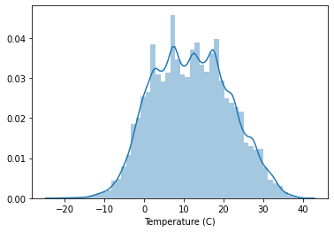

```python
#collapse-hide

import seaborn as sns
sns.distplot(dataframe_raw['Temperature (C)'])
```

Explorando se a variável *target* tem alguma relação linear com a variável *humidade*, como destacado no plot temos uma relação linear negativa, ou seja, quando a temperatura abaixa a humidade do ar aumenta.

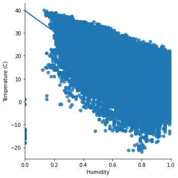

```python
#collapse-hide

sns.lmplot(x="Humidity", y="Temperature (C)", data=df,
           order=2, ci=None);
```

### Step 2: Preparação do Dataset

Esta função `dataframe_to_arrays` recebe como argumento o dataframe e utiliza da biblioteca `numpy` para converter as colunas de formato texto para datados categóricos para assim utilizar o método `.cat.codes` que associará a cada valor categórico um código.

Por fim ela converte os dados na `input_cols` e `output_cols` para o formato de array utilizando `to_numpy()` e retorna os dois arrays `inputs_array` e `targets_array`

```python
#collapse-hide

import numpy as np
def dataframe_to_arrays(dataframe):
    # Make a copy of the original dataframe
    dataframe1 = dataframe.copy(deep=True)
    # Convert non-numeric categorical columns to numbers
    for col in categorical_cols:
        dataframe1[col] = dataframe1[col].astype('category').cat.codes
    # Extract input & outupts as numpy arrays
    inputs_array = dataframe1[input_cols].to_numpy()
    targets_array = dataframe1[output_cols].to_numpy()
    return inputs_array, targets_array
```

```python
#collapse-hide

inputs_array, targets_array = dataframe_to_arrays(df)
inputs_array, targets_array
```

```
(array([[  19.        ,    0.        ,    7.38888889, ...,    0.        ,
         1015.13      ,  197.        ],
        [  19.        ,    0.        ,    7.22777778, ...,    0.        ,
         1015.63      ,  197.        ],
        [  17.        ,    0.        ,    9.37777778, ...,    0.        ,
         1015.94      ,  197.        ],
        ...,
        [  19.        ,    0.        ,   22.03888889, ...,    0.        ,
         1015.66      ,  170.        ],
        [  19.        ,    0.        ,   21.52222222, ...,    0.        ,
         1015.95      ,  170.        ],
        [  19.        ,    0.        ,   20.43888889, ...,    0.        ,
         1016.16      ,  170.        ]]), array([[ 9.47222222],
        [ 9.35555556],
        [ 9.37777778],
        ...,
        [22.03888889],
        [21.52222222],
        [20.43888889]]))
```

Como destacado na sequencia de passaos [e importante converter os dados do para o formato de Tensor para ser utilizado pelo PyTorch.

Destaco a necessidade de converter com tipo `torch.float32`, o pytorch como documentado na documentação [torch.tensors](https://pytorch.org/docs/stable/tensors.html) precisa trabalhar com tipo float e float64 é um double tensor que não se aplica neste caso. Por isso a utilização de float32.

```python
#collapse-hide

inputs = torch.from_numpy(inputs_array).type(torch.float32)
targets = torch.from_numpy(targets_array).type(torch.float32)
inputs.dtype, targets.dtype
```

```
(torch.float32, torch.float32)
```

Nesta etapa do projeto precisamos preparar o dataset para treinamento, utilizando `TensorDataset` convertemos cada exemplo em um vetor 1D.

```python
#collapse-hide

dataset = TensorDataset(inputs, targets)
```

```python
#collapse-hide

val_percent = 0.1
num_rows = len(df)
num_cols = len(df.columns)
val_size = int(num_rows * val_percent)

train_size = num_rows - val_size


train_ds, val_ds = random_split(dataset, [train_size, val_size]) # Use the random_split function to split dataset into 2 parts of the desired length
```

A variável `batch_size` será utilizada para dividir os dados na hora do treinamento, para isso criamos o `train_loader` e `val_loader` .

Na documentação do PyTorch [torch.utils.data](https://pytorch.org/docs/stable/data.html) o DataLoader é o coração do PyTorch, ele realizará toda iteração do dataset, neste caso o parametro `Shuffle=True` irá "embaralhar" os dados a cada epoch.

```python
batch_size = 32
```

```python
#collapse-hide

train_loader = DataLoader(train_ds, batch_size, shuffle=True)
val_loader = DataLoader(val_ds, batch_size)
```

### Step 3 : Criação do modelo de Regressão Linear

```python
#collapse-hide

input_size = len(input_cols)
output_size = len(output_cols)
input_size,output_size
```

```
(10, 1)
```

A classe `CALCOFI_Model` define os métodos que definie o modelo

- **init** : No método construtor cria-se o objeto linear a partir do `nn.Linear` que recebe dois parametros : Input e Output
- **foward** : O médodo forward recebe o input e retorna o output
- **training_step** : No step de treinamento é extraido do batch o input e target e calculado o erro , no caso abaixo utilizei o l1_loss, neste link [Loss Function](https://pytorch.org/docs/master/nn.html#loss-functions) temos a documentação de todas as opções de loss do PyTorch.
- **validation_Step** : Similar ao realizado no treinamento o passo de validação faz o cáculo de loss no dataset de validação
- **validation_epoch_end** : Este médodo consolida os calulos da epoch para ser apresentado
- **epoch_end** : Apresenta o resultado a cada 20 epochs

```python
class CAlCOFI_Model(nn.Module):
    def __init__(self):
        super().__init__()
        self.linear = nn.Linear(input_size, output_size)

    def forward(self, xb):
        out = self.linear(xb)
        return out

    def training_step(self, batch):
        inputs, targets = batch
        # Generate predictions
        out = self(inputs)
        # Calcuate loss
        loss = F.l1_loss(out,targets)
        return loss

    def validation_step(self, batch):
        inputs, targets = batch
        # Generate predictions
        out = self(inputs)
        # Calculate loss
        loss = F.l1_loss(out,targets)
        return {'val_loss': loss.detach()}

    def validation_epoch_end(self, outputs):
        batch_losses = [x['val_loss'] for x in outputs]
        epoch_loss = torch.stack(batch_losses).mean()
        return {'val_loss': epoch_loss.item()}

    def epoch_end(self, epoch, result, num_epochs):
        # Print result every 20th epoch
        if (epoch+1) % 20 == 0 or epoch == num_epochs-1:
            print("Epoch [{}], val_loss: {:.4f}".format(epoch+1, result['val_loss']))

model = CAlCOFI_Model()
```

Estes são os parametros do modelo :

```python
#collapse-hide

list(model.parameters())
```

```
[Parameter containing:
 tensor([[ 0.1257,  0.2043,  0.1329, -0.0199,  0.2992, -0.1360,  0.0997,  0.1371,
           0.1450,  0.1588]], requires_grad=True), Parameter containing:
 tensor([0.3016], requires_grad=True)]
```

### Step 4 : Treinamento do modelo

Para realizar o treinamento temos dois métodos:

- **evaluate** : Método de avaliação do modelo
- **fit** : Método onde o treinamento acontece, ele recebe diversos parametros como:
  - epochs : número de epochs
  - lr : learning rate
  - model : modelo
  - train_loader : dataset preparado para treino
  - val_loader : dataset preparado para validação
  - opt_func : função de otimização, neste exercício será utilizado o [torch.optin.SGD](https://pytorch.org/docs/1.2.0/_modules/torch/optim/sgd.html), que implementa o método de otimização de gradiente descendente. Neste link temos diversos outros métodos de otimização [torch.optim](https://pytorch.org/docs/stable/optim.html)

o *Fit* é composto de 3 seguimentos:

1 - Lista `history` que armazena o resultado por epoch

2 - `optimizer` que faz a otimiza,ão do modelo com base nos parametros e learning rate

3 - Primeiro loop for que percorre cada epoch e um segundo loop for interno que percorre o train_loader por batch, calculando o *loss* o *slope* e assim é realizado a otimização , ao final é feita a avaliação da epoch e armazenado o resultado no `history`

```python
def evaluate(model, val_loader):
    outputs = [model.validation_step(batch) for batch in val_loader]
    return model.validation_epoch_end(outputs)

def fit(epochs, lr, model, train_loader, val_loader, opt_func=torch.optim.SGD):
    history = []
    optimizer = opt_func(model.parameters(), lr)
    for epoch in range(epochs):
        # Training Phase
        for batch in train_loader:
            loss = model.training_step(batch)
            loss.backward()
            optimizer.step()
            optimizer.zero_grad()
        # Validation phase
        result = evaluate(model, val_loader)
        model.epoch_end(epoch, result, epochs)
        history.append(result)
    return history
```

```python
##collapse-hide

result = evaluate(model,val_loader ) # Use the the evaluate function
print(result)
```

```
{'val_loss': 136.86151123046875}
```

Neste primeiro ciclo de treinamento criado o history1 composto de 10 epochs e um learning rate de 1e-2, podemos observar que o erro no validation é bem alto **val_loss: 8791.4219**

```python
epochs =  10
lr = 1e-2
history1 = fit(epochs, lr, model, train_loader, val_loader)
```

```
Epoch [10], val_loss: 8791.4219
```

No segundo ciclo de expeerimento adicionei mais epochs, para um total de 30 com o mesmo learning rate, ao final de 30 epochs o obtive o seguinte val_loss: 3514.0930, importante ver que tive um certo "salto" grande entre o erro de 20 para 30 epochs, o que indica que devo diminuir o learning rate

```python
epochs =  30
lr = 1e-2
history2 = fit(epochs, lr, model, train_loader, val_loader)
```

```
Epoch [20], val_loss: 6955.5908
Epoch [30], val_loss: 3514.0930
```

Aumentando o número de epochs para 100 e diminuindo o learning rate para 1e-6 tivemos um decrescimo do learning rate sem saltos grandes o que indica que o modelo foi aprendendo aos poucos

```python
epochs =  100
lr = 1e-6
history3 = fit(epochs, lr, model, train_loader, val_loader)
```

```
Epoch [20], val_loss: 15.2285
Epoch [40], val_loss: 13.2498
Epoch [60], val_loss: 11.3344
Epoch [80], val_loss: 9.4787
Epoch [100], val_loss: 7.7381
```

### Step 5 : Avaliação do Modelo e Predição

Para avaliação do erro de treinamento por epoch foi criado a função `plot_losses`

```python
def plot_losses(history):
    losses = [x['val_loss'] for x in history]
    plt.plot(losses, '-x')
    plt.xlabel('epoch')
    plt.ylabel('loss')
    plt.title('Loss vs. No. of epochs')
```

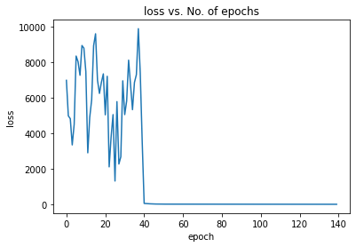

```python
#collapse-hide

loss = []
for value in history1+history2+history3:
    loss.append(value['val_loss'])
plt.xlabel('epoch')
plt.ylabel('loss')
plt.title('loss vs. No. of epochs');
plt.plot(loss)
```

Pode-se observar que o modelo foi aprendendo aos pocuso e errando cada vez menos

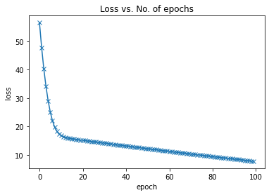

```python
plot_losses(history3)
```

Para realizar a predição foi criado a função `predict_single` que recebe como parametro o input o target e o modelo

```python
 def predict_single(input, target, model):
    inputs = input.unsqueeze(0)
    predictions = model(inputs)
    prediction = predictions[0].detach()
    print("Input:", input)
    print("Target:", target)
    print("Prediction:", prediction)
```

Nos dois exemplos a seguir podemos ver que o modelo erro muito inferindo uma temperatura de -10.77 quando foi 12.26, e 17.9 quando foi 8.91

```python
input, target = val_ds[2]
predict_single(input, target, model)
```

```
Input: tensor([1.7000e+01, 0.0000e+00, 1.2267e+01, 9.3000e-01, 2.7451e+01, 1.5000e+02,
        1.1978e+01, 0.0000e+00, 1.0155e+03, 1.1100e+02])
Target: tensor([12.2667])
Prediction: tensor([-10.7706])
```

```python
input, target = val_ds[10]
predict_single(input, target, model)
```

```
Input: tensor([1.9000e+01, 0.0000e+00, 8.9167e+00, 5.7000e-01, 4.6046e+00, 2.0000e+01,
        1.6100e+01, 0.0000e+00, 1.0219e+03, 1.8100e+02])
Target: tensor([8.9167])
Prediction: tensor([17.9243])
```

## Conclusão

Pode-se observar que a mesma abordagem para solucionar o problema de insuranse foi utilizada para o problema de temperatura, porém este precisa de alguns ajustes e testes como , aumentar o número de layears, treinar por mais tempo e mais epochs.